# Cholera data exploration

Seth Caldwell

2023-05-15

## Cholera exploration

CERF has been scraping data from WHO AFRO emergency bulletins. We want to see how this data compares with CERF allocations, as we don’t currently have an additional source of cholera case data.

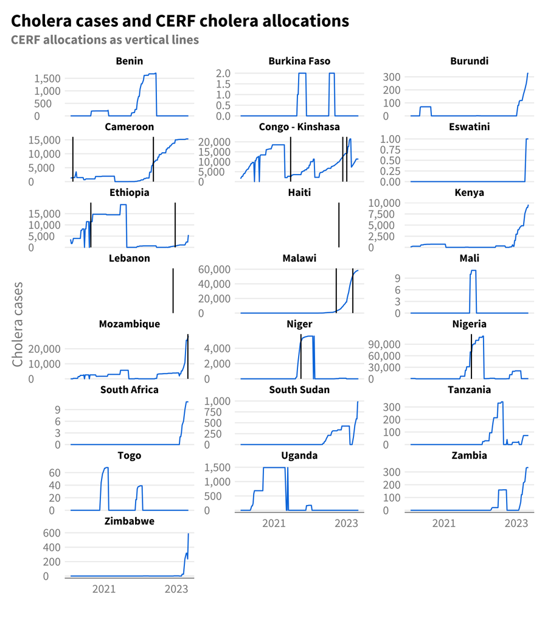

From the above, we can definitely see a relationship between cholera cases and CERF allocations (obviously) and it isn’t always the case that CERF is allocating after to the peak of an outbreak. What if we activated if there was a first case reported after no cases and once the total caseload reaches 1,000, 5,000 or 10,000 cases.

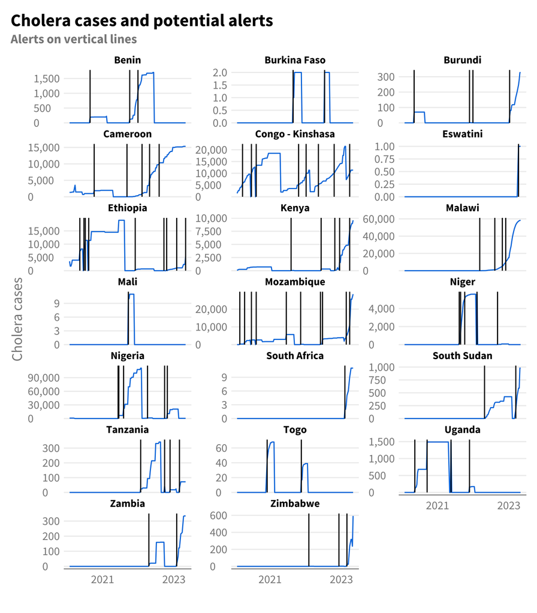

Here, the alerts are potentially too frequent in some cases, and not always due to rapid rises in caseload, such as in Ethiopia and Mozambique. Let’s limit the alerts to only happening if that particular alert also hasn’t activated in the past month, to reduce this frequency, but still allow rapid alerts if the rise in caseloads is particularly rapid or alarming.

First, just look at the simple relationship.

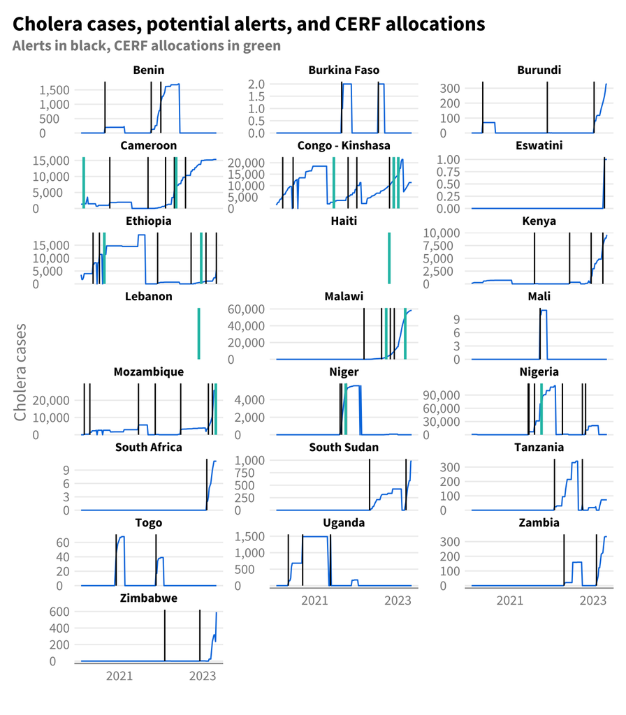

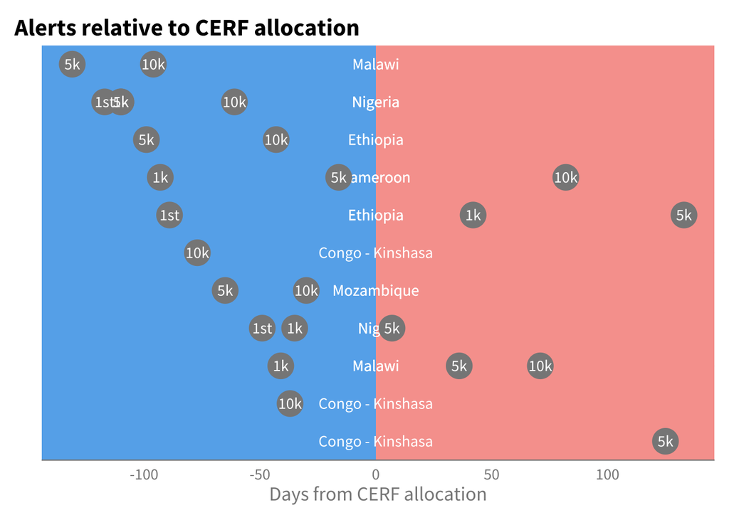

Overall, we can see that our alerts would have activated prior to nearly all CERF allocations. There are some outliers, such as in the DRC but looking at that country, it’s unclear how and when outbreaks are calculated in the data CERF is scraping. Overall, we should feel pretty confident that we have some signal prior to activation.

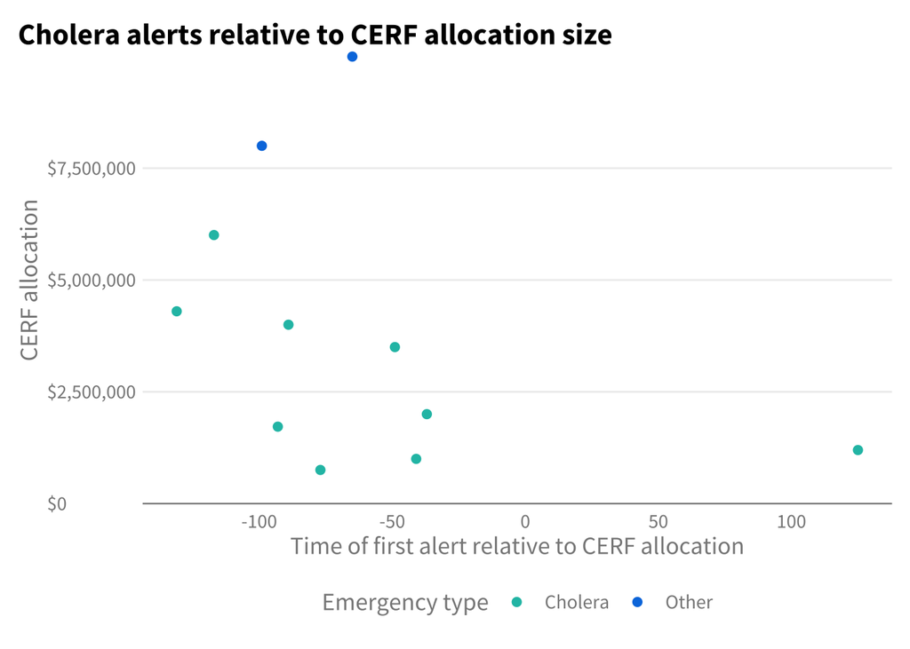

We can see that the alerts also generate earliest relative to the largest CERF allocations. This makes sense, as the longer CERF takes to respond, the more likely that any response would be to a much more widesrpread outbreak. Thus, the potential for speeding up allocations to new outbreaks by notifying CERF of their occurrence could have potentially high value.

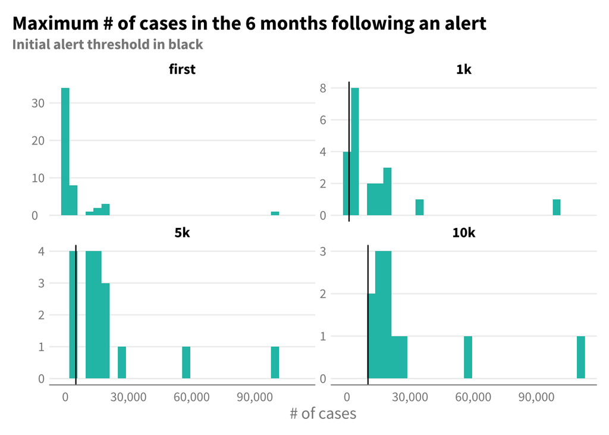

From the above, it’s clear that once an alert threshold reaches 5k or 10k, the cholera cases generally tend to grow exponentially larger. This is less the case for when there is the first cholera case and slightly less so for 1k threshold, but still a relatively high percent. Let’s have a look at those actual trends from the date of alert to 6 months later

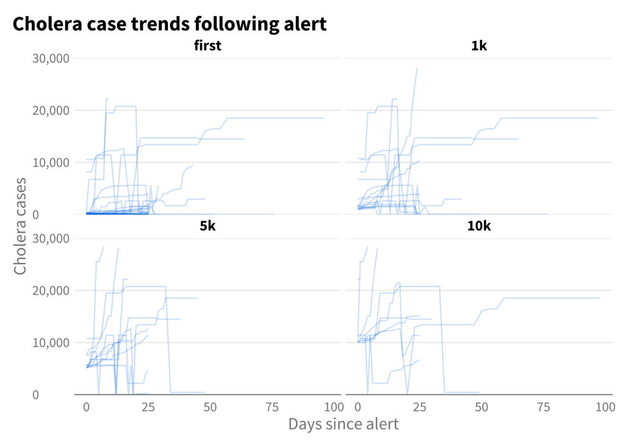

It can still be hard to see the trends above, so let’s simply look at the percent of alerts that are followed by another alert. That is, what % of alerts for the 1st case of cholera eventually see a future alert for 1,000 cases and so on.

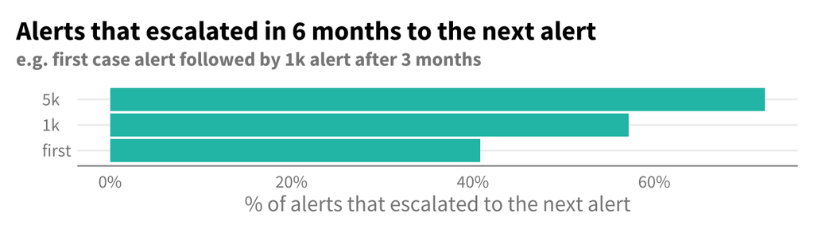

Above, we can see that 40% of alerts from a first case escalate in the next 6 months eventually to over 1,000 cases. Of course, we don’t want to interpret these directly as true or false positives, but that 40% (and the increasing percents at higher levels) are quite high and indicate the value of alerting across these levels to ensure CERF is aware of any onsets or escalations.